# NIH Exporter: Database Import and Analysis

Harris Dupre

12/8/2019

# Introduction

This project seeks to import the publicly available NIH data into a database for storage and analysis. This data will be matched to a dummy database of employee information, to demonstrate the types of analyses that could be performed.

The script data_scrape.R (https://github.com/hdupre/DATA607/blob/master/nih_exporter/data_scrape.R), contains the code for scraping the zip files from the NIH Exporter website and unpacking the CSVs in the local environment.

Unfortunately, persistent issues meant that some manual intervention was needed between the extraction of the CSVs and loading them into the database, so the entirety of the process was not able to be knitted together in one RMD file.

#### Issues:

- Some datasets (2010-2013) had missing or misspelled fields, which caused the dataframe that all the CSVs are loaded into to add extra fields to accomodate this.
- There are UTF8 encoding issues. The CSVs had to be opened in a text editor and saved with a UTF8 encoding in order to avoid errors during the database load. Some invisible characters in three of the fifty-three datasets from 2019 (as 2019 and 2020 have one CSV for each week of the year) caused such persistent issues that it was better to remove them from the upload entirely – three weeks of missing data should not make a large difference in the aggregate analyses we will perform.

**Creating a list of files, converting to a dataframe, loading to the database.**

```r
library(RCurl)
library(XML)
library(stringr)
library(plyr)
library(readr)
library(RMySQL)

# Set the directory where the unzipped CSVs are stored (these CSVs were retrieved in data_scrape.R linked above).
mydir <- "~/nih_exporter/CSVs/data"

# Make a list of csv file names at the set location.
myfiles <- list.files(path=mydir, pattern="*.csv", full.names=TRUE)

# Ignore all datasets from before 2010 for simplicity -- a ten year lookback is sufficient for these purposes.
myfiles <- myfiles[26:95]

# Remove three files from fiscal year 2019 that were having persistent issues due to invisible UTF8 characters.
myfiles <- myfiles[-c(51,59,60)]

# Read each CSV into dat_csv. Making the column types explicit avoids the persistent issue of some columns being erroneously labeled col_logical().
dat_csv = ldply(myfiles, read_csv, col_names= TRUE, col_types=cols(
  APPLICATION_ID = col_double(),
  ACTIVITY = col_character(),
  ADMINISTERING_IC = col_character(),
  APPLICATION_TYPE = col_double(),
  ARRA_FUNDED = col_character(),
  AWARD_NOTICE_DATE = col_character(),
  BUDGET_START = col_character(),
  BUDGET_END = col_character(),
  CFDA_CODE = col_character(),
  CORE_PROJECT_NUM = col_character(),
  ED_INST_TYPE = col_character(),
  FOA_NUMBER = col_character(),
  FULL_PROJECT_NUM = col_character(),
  FUNDING_ICs = col_character(),
  FUNDING_MECHANISM = col_character(),
  FY = col_double(),
  IC_NAME = col_character(),
  NIH_SPENDING_CATS = col_character(),
  ORG_CITY = col_character(),
  ORG_COUNTRY = col_character(),
  ORG_DEPT = col_character(),
  ORG_DISTRICT = col_double(),
  ORG_DUNS = col_character(),
  ORG_FIPS = col_character(),
  ORG_IPF_CODE = col_double(),
  ORG_NAME = col_character(),
  ORG_STATE = col_character(),
  ORG_ZIPCODE = col_character(),
  PHR = col_character(),
  PI_IDS = col_character(),
  PI_NAMEs = col_character(),
  PROGRAM_OFFICER_NAME = col_character(),
  PROJECT_START = col_character(),
  PROJECT_END = col_character(),
  PROJECT_TERMS = col_character(),
  PROJECT_TITLE = col_character(),
  SERIAL_NUMBER = col_character(),
  STUDY_SECTION = col_character(),
  STUDY_SECTION_NAME = col_character(),
  SUBPROJECT_ID = col_double(),
  SUFFIX = col_character(),
  SUPPORT_YEAR = col_double(),
  DIRECT_COST_AMT = col_double(),
  INDIRECT_COST_AMT = col_double(),
  TOTAL_COST = col_double(),
  TOTAL_COST_SUB_PROJECT = col_double()
))

head(dat_csv)
```

```
##   APPLICATION_ID ACTIVITY ADMINISTERING_IC APPLICATION_TYPE ARRA_FUNDED
## 1        7000731      C06               RR                1           Y
## 2        6826709      C06               RR                1           Y
## 3        7000889      C06               RR                1           Y
## 4        7000560      C06               RR                1           Y
## 5        7000669      C06               RR                1           Y
## 6        6949832      C06               RR                1           Y
##   AWARD_NOTICE_DATE BUDGET_START BUDGET_END CFDA_CODE CORE_PROJECT_NUM
## 1        10/20/2009   10/20/2009  9/30/2013       702      C06RR020081
## 2        10/20/2009   10/20/2009 10/19/2014       702      C06RR020088
## 3         12/9/2009   12/10/2009  6/30/2014       702      C06RR020096
## 4        10/20/2009   10/20/2009 10/19/2014       702      C06RR020132
## 5         12/9/2009   12/10/2009  6/30/2015       702      C06RR020533
## 6        10/20/2009   10/20/2009  9/30/2013       702      C06RR020544
##                     ED_INST_TYPE    FOA_NUMBER  FULL_PROJECT_NUM
```

[output cut: 83 more lines]

```r
# Set the MySQL connection variable, with the local database nih_export.
conn = dbConnect(MySQL(), user = 'root', password = '', dbname = 'nih_export', host = 'localhost')

# Write the data to a table in nih_export called nih_data.
dbWriteTable(conn, "nih_data", dat_csv, overwrite = TRUE, row.names=FALSE)
```

```
## [1] TRUE
```

**Creating a dummy employee database**

Here we will take two prepared CSVs: employee_db and application_employee_id.

The former is a dummy employee table containing employee ID, name, title, department, and salary.

The latter is table containing application IDs and employee IDs, this will help join the employee_db table to the nih_data table so that analyses can be run on internal data and the NIH data.

```r
# Set the working directory to where the CSVs are.
setwd("~/nih_exporter")

# Read in the employee CSV and load it to the database.
employee_df <- read.csv("employee_db.csv", sep=",")

head(employee_df)
```

```
##   employee_id  first       last               title        department
## 1    33981637  David    Caffrey Assistant Professor Internal Medicine
## 2    21129270 Edward      Jones Assistant Professor Internal Medicine
## 3    13832369   Erin     Gordon Assistant Professor Internal Medicine
## 4    86042845  Ethel    Webster Assistant Professor Internal Medicine
## 5    16425582  Frank      Smith Assistant Professor Internal Medicine
## 6    36328276   Fred Blackstock Assistant Professor Internal Medicine
##   salary
## 1  72516
## 2  54820
## 3  50333
## 4  52502
## 5  66733
## 6  65997
```

```r
dbWriteTable(conn, "employees", employee_df, overwrite = TRUE, row.names = FALSE)
```

```
## [1] TRUE
```

```r
# Read in the application/employee ID CSV and load it to the database.
app_emp_df <- read.csv("application_employee_id.csv", sep=",")

head(app_emp_df)
```

```
##   application_id employee_id
## 1        9734439    33981637
## 2        9710474    21129270
## 3        9859520    13832369
## 4        9518924    86042845
## 5        9488276    16425582
## 6        9704737    36328276
```

```r
dbWriteTable(conn, "app_emp_id", app_emp_df, overwrite = TRUE, row.names = FALSE)
```

```
## [1] TRUE
```

**Creating dataframes, joining tables**

To create the dataframes we’ll use for analysis we’ll need to query the db and join tables

```r
nyu_dept_df <- dbGetQuery(conn, statement = paste("SELECT
ORG_DEPT, TOTAL_COST
FROM
nih_data
WHERE
ORG_NAME = 'NEW YORK UNIVERSITY SCHOOL OF MEDICINE' AND
FY = 2019;"))

pediatrics_df <- dbGetQuery(conn, statement = paste("SELECT
FY, TOTAL_COST
FROM
nih_data
WHERE
ORG_NAME = 'NEW YORK UNIVERSITY SCHOOL OF MEDICINE' AND
ORG_DEPT = 'PEDIATRICS';"))


ratio_df <- dbGetQuery(conn, statement = paste("SELECT nih_data.TOTAL_COST, employees.first, employees.last, employees.salary
FROM app_emp_id
    INNER JOIN nih_data
        on app_emp_id.application_id = nih_data.APPLICATION_ID
    INNER JOIN employees
        on app_emp_id.employee_id = employees.employee_id;"))

title_df <- dbGetQuery(conn, statement = paste("SELECT nih_data.TOTAL_COST, employees.title, employees.department
FROM app_emp_id
    INNER JOIN nih_data
        on app_emp_id.application_id = nih_data.APPLICATION_ID
    INNER JOIN employees
        on app_emp_id.employee_id = employees.employee_id;"))

head(nyu_dept_df)
```

```
##                        ORG_DEPT TOTAL_COST
## 1                    PEDIATRICS     914716
## 2                     PATHOLOGY     423750
## 3   MICROBIOLOGY/IMMUN/VIROLOGY     537588
## 4                  BIOCHEMISTRY     803630
## 5                     PATHOLOGY     211875
## 6 RADIATION-DIAGNOSTIC/ONCOLOGY     497396
```

```r
head(pediatrics_df)
```

```
##     FY TOTAL_COST
## 1 2010      47606
## 2 2010     605310
## 3 2010     220545
## 4 2010     244779
## 5 2010     762666
## 6 2010     570867
```

```r
head(ratio_df)
```

```
##   TOTAL_COST   first     last salary
## 1     199643    Greg      Lee 105082
## 2     286918  Andrea Martinez 253686
## 3    1251118 Jeffrey    Rosen  68927
## 4     223312 Jessica    Riolo 128572
## 5     120000    Jane    Rogan  52123
## 6     286676     Adi    Allon 267107
```

```r
head(title_df)
```

```
##   TOTAL_COST               title        department
## 1     199643 Associate Professor   Plastic Surgery
## 2     286918           Professor Internal Medicine
## 3    1251118 Assistant Professor          Oncology
## 4     223312 Associate Professor          Oncology
## 5     120000 Assistant Professor          Oncology
## 6     286676           Professor Internal Medicine
```

**Transformation**

With the data loaded into dataframes, we can transform and analyze.

```r
library(dplyr)
```

```r
library(ggplot2)

# Group by department, then sum total dollars awarded per department.
nyu_dept_df <- group_by(nyu_dept_df, ORG_DEPT)
nyu_dept_df <- summarize(nyu_dept_df, sum_total_cost = sum(TOTAL_COST))
nyu_dept_df <- data.frame(nyu_dept_df)
nyu_dept_df <- nyu_dept_df[1:21,]

# Plot results in a bar chart.
nyu_dept_plot <- ggplot(nyu_dept_df, aes(x=ORG_DEPT,y = sum_total_cost)) +
    geom_bar(width = .75,stat = "identity", position="dodge") +
    ggtitle("Total $ Awarded by Department, FY2019") +
    labs(x="Department",y="Total $ Awarded") +
    theme(plot.title = element_text(hjust=0.5), axis.text.x = element_text(angle = 90, hjust = 1)) +
    scale_y_continuous(labels = scales::dollar_format(prefix="$"))

# Group by fiscal year, then sum total dollars awarded per fiscal year.
pediatrics_df <- group_by(pediatrics_df, FY)
pediatrics_df <- summarize(pediatrics_df, sum_total_cost = sum(TOTAL_COST))
pediatrics_df <- data.frame(pediatrics_df)

# Plot a time-series
pediatrics_plot <- ggplot(pediatrics_df, aes(x=FY, y=sum_total_cost)) +
  geom_line(color = 'blue', size = 1) +
  ggtitle("Pediatrics Total Award $, FY 2010-20") +
  labs(x="Fiscal Year",y="Total $ Awarded") +
  theme(plot.title = element_text(hjust=0.5)) +
  scale_y_continuous(labels = scales::dollar_format(prefix="$")) +
  scale_x_continuous(breaks = seq(2010,2020,by=1))

# Calculate the ratio of salary to award dollars for each employee.
ratio_df <- mutate(ratio_df, award_salary_ratio = round((salary/TOTAL_COST)*100,1))

# Group by title and department and sum total award $.
title_df <- group_by(title_df, title, department)
title_df <- summarize(title_df, sum_total_cost = sum(TOTAL_COST))
title_df <- data.frame(title_df)

# Plot in a bar chart where the x-axis is title and the fill is department.
title_plot <- ggplot(title_df, aes(x=title,y = sum_total_cost, fill = department)) +
    geom_bar(width = .75,stat = "identity", position="dodge") +
    ggtitle("Total $ Awarded per Title by Department") +
    labs(x="Title",y="Total $ Awarded", fill="Department") +
    theme(plot.title = element_text(hjust=0.5)) +
    scale_y_continuous(labels = scales::dollar_format(prefix="$"))
```

**Analysis and Conclusions**

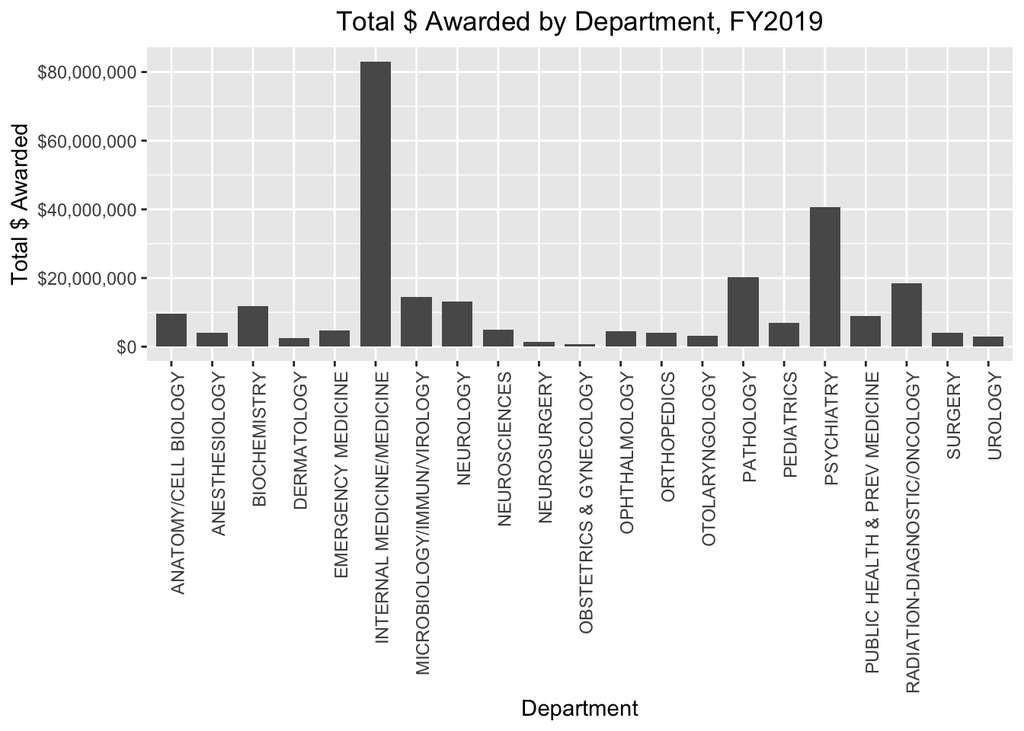

```r
nyu_dept_plot
```

Here we can see that in FY2019, Internal Medicine was awarded the most federal dollars by a large margin.

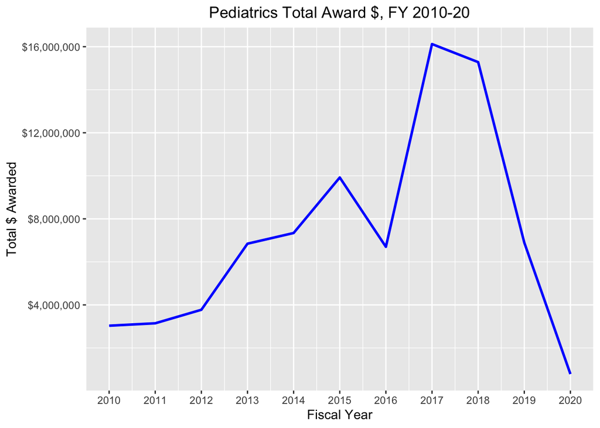

```r
pediatrics_plot
```

Award dollars for the pediatrics department have generally increased in the past ten years, with FY2017 and FY2018 being particularly good.

```r
ratio_df
```

```
##    TOTAL_COST     first       last salary award_salary_ratio
## 1      199643      Greg        Lee 105082               52.6
## 2      286918    Andrea   Martinez 253686               88.4
## 3     1251118   Jeffrey      Rosen  68927                5.5
## 4      223312   Jessica      Riolo 128572               57.6
## 5      120000      Jane      Rogan  52123               43.4
## 6      286676       Adi      Allon 267107               93.2
## 7      265664     Paolo Churchhill  91246               34.3
## 8      190400      Gary       Ngai 119694               62.9
## 9      297266      Kirk     Hubman 212883               71.6
## 10     208520      Jack      Smith 119495               57.3
## 11     184890 Elizabeth     Hudson  93058               50.3
## 12    2502236      Mady     Downey 115686                4.6
## 13     299317       Max      Huang 297977               99.6
## 14     155500     Ricky    Freeman  58381               37.5
```

[output cut: 46 more lines]

Employees with a low score are bringing in far more dollars than their salary amount. Those with a score over 100 are costing more than they’re bringing in with grants.

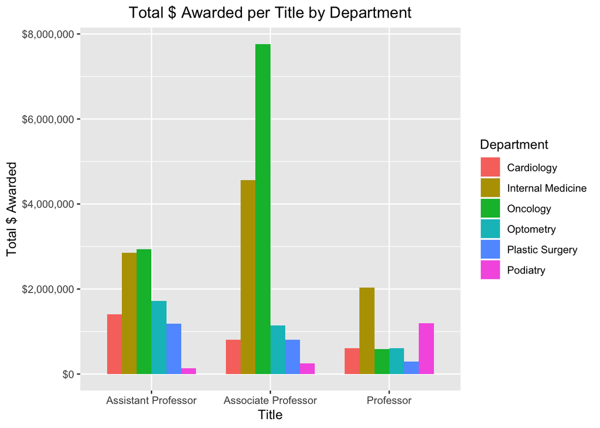

```r
title_plot
```

This is dummy data, so these conclusions aren’t applicable to the real world, but this type of analysis could allow for some investigation into why, for example, Associate Professors in Oncology are able to bring in so many award dollars.